# 0607

## 模型結構

$$\bf g(\mu) = \eta = X \beta+ b = X \beta+ M v$$
$$\bf M = ZL \ or \ ZAL$$

- $g(.)$ : link function
- $\bf b$ : 隨機效應，由已知的 “design matrix” $ Z$ 與 $\boldsymbol v$ 組成。
  - 若隨機效應彼此之間有關係（$\bf u$ not indepoendent），則可以將隨機效應表示成 $\bf Mv$, $\bf M = ZL \ or \ ZAL$
  - $\bf Z$: 通常是一個關聯矩陣,兩者相鄰為1，不相鄰為0。
  - $\bf A$: The optional A factor can also be given by the optional “AMatrices” attribute of covStruct.
  - $\bf L$: 對於空間的隨機效應來說，通常為**Cholesky “square root”**，由Matern等距離相關矩陣分解而成。(For spatial random effects, L is typically the Cholesky “square root” of a correlation matrix determined by the random effect specification (e.g., Matern(…))
- $\lambda$ 為隨機效應(Random effect)的變異數(Variance)，$\phi$ 為殘差(Residuals)的變異數(Variance)。

`spaMM` 會提供固定效應的參數($\boldsymbol \beta$)的估計與隨機效應的分布情形（the variances of $u_i$ and of the residual error $e_i$）以及 $\boldsymbol Z$ 的相關係數(在空間模型的情況下，例如 Matern 的$\rho , \nu$)

### Matérn covariance function

是統計學中的一個協方差函數。它常被用於定義兩點測量值之間的協方差。由於該協方差只取決於**兩點間的距離**，因而是平穩的。如使用**歐幾里得**距離來定義距離，此時的馬特恩協方差函數是各向同性的。(取自維基百科)

因此通常使用該協方差矩陣來解釋空間之間的相關性。

$$C_{\nu}(d) = {\sigma^2}\frac{2^{1-\nu}}{\Gamma(\nu)}(\sqrt{2\nu}\frac{d}{\rho})K_{\nu}(\sqrt{2\nu}\frac{d}{\rho})$$

- $d$: 兩點的距離
- $\Gamma(.)$: $\Gamma(.)$ 函數
- $\rho, \nu$: 非負參數，$\rho$ 為 scale parameter(尺度參數)，$\nu$ 為 smoothing parameter(平滑參數)，越大越平滑
- ${\displaystyle K_{\nu }}$: 第二類貝索函數

當$\nu \rightarrow \infty$:

$$\mathop{lim}\limits_{\nu \rightarrow \infty} C_{\nu}(d) = {\sigma^2}exp(-\frac{d^2}{\rho^2})$$

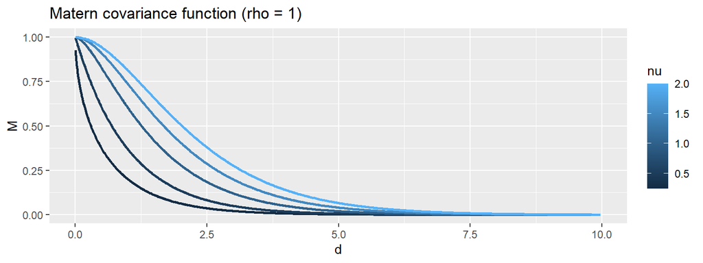

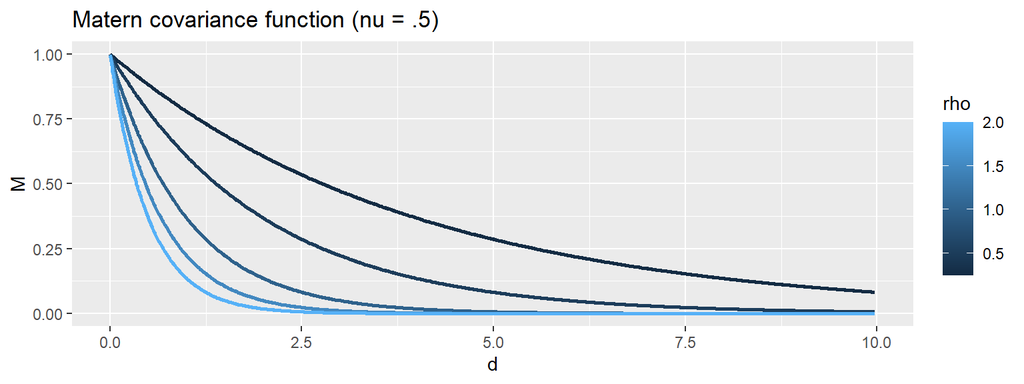

## Cauchy covariance function

$$C_{cau}(d) = (1-Nuggest)(1+(\rho d)^{\nu})(longdep/\nu))$$

- $Nuggest$: 金塊效應，算是某種誤差
- $\rho$: `rho`，尺寸參數(scaling factor)
- $\nu$:`shape`，形狀（平滑）參數，若距離為歐式距離，$0< \nu \leq 2$；若為大圓距離 (Great-circle distance)，$0< \nu \leq 1$。
- $longdep$: `longdep`，給出相關性隨距離漸近減小的指數，大於零的實數。

## Model fitting

#### COMPoisson family

Conway-Maxwell-Poisson 是以計數型的 Poisson 為基礎發展出來的分配，是為了解決那些過度分散或者過度集中(over- and underdispersion)的計數型分配。

$$Pr(y;\lambda, \nu_{CMP}) = \frac{\lambda^y}{(y!)^{\nu_{CMP}}Z(\lambda, \nu_{CMP})}$$
$$Z(\lambda, \nu_{CMP}) = \sum^ \infty_{k=0}\frac{\lambda^k}{(k!)^{\nu_{CMP}}}$$
- $\nu_{CMP}$: 其值越小，分布程度越廣(overdispersion); 其值越大，分布程度越集中(underdispersion);$\nu_{CMP} = 1$ 的時候就是 poisson 分配。

### Model 01

- package: spaMM
- family = COMPoisson()
- 變數：層級(p.s. 台北市沒有)、戶量、里面積（平方公里）
- 關聯矩陣：Cauchy、Matern (參數 `spaMM` 會給)

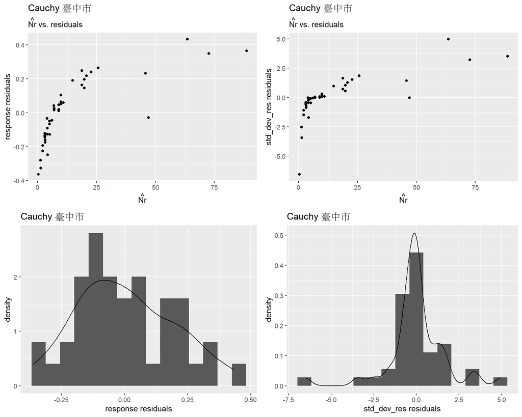

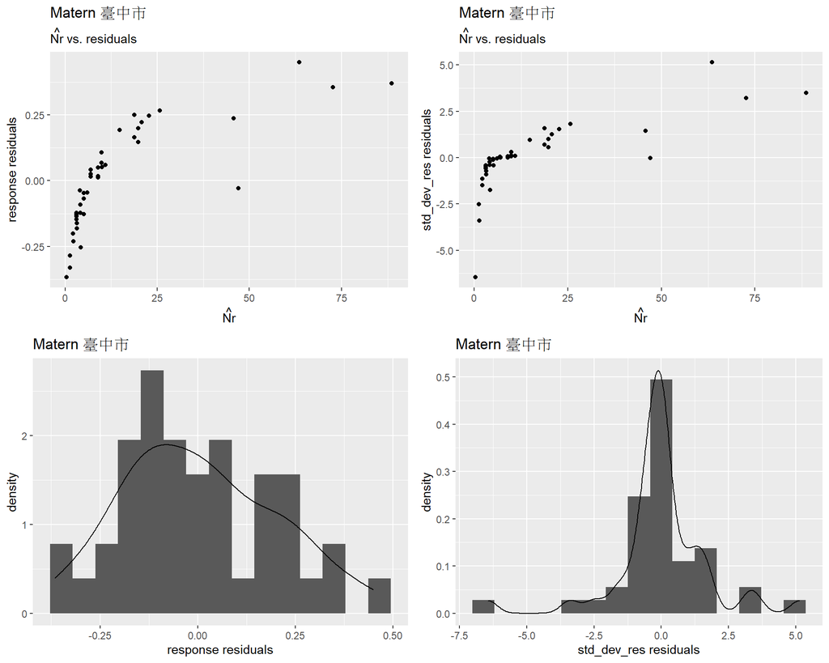

### Model 02

- package: spaMM
- family = COMPoisson()
- 變數：層級(p.s. 台北市沒有)、戶量、offset(里面積（平方公里）)
- 關聯矩陣：Cauchy、Matern (參數 `spaMM` 會給)

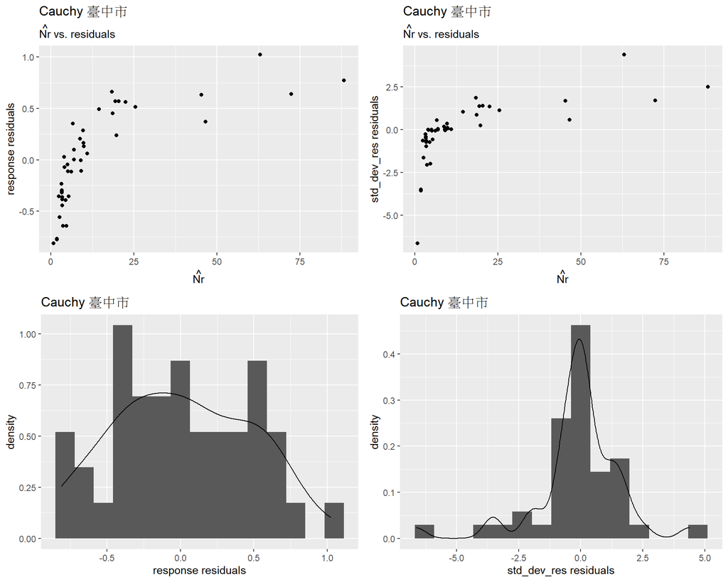

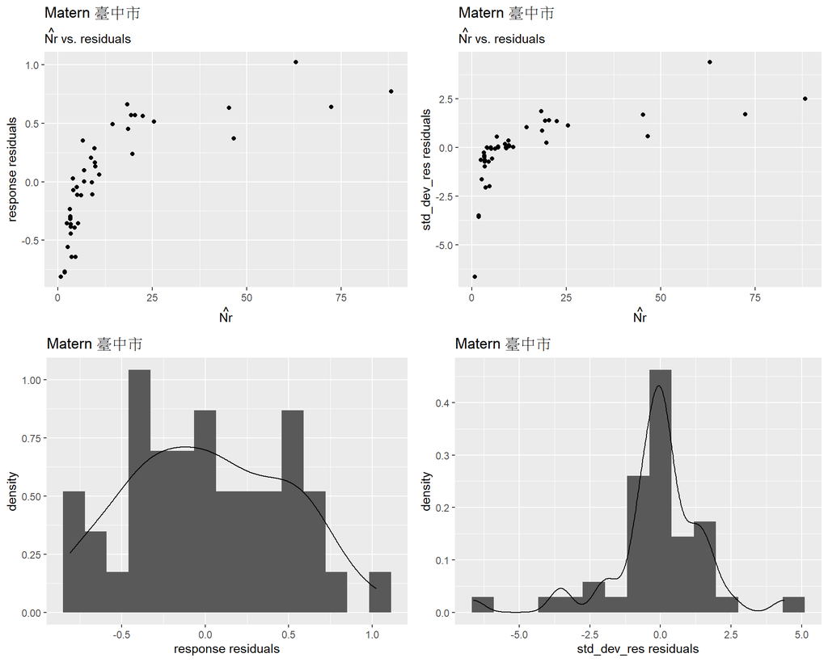

### Model 03

- package: spaMM
- family = negbin()
- 變數：層級(p.s. 台北市沒有)、戶量、offset(log(里面積（平方公里）))
- 關聯矩陣：Cauchy、Matern (參數 `spaMM` 會給)

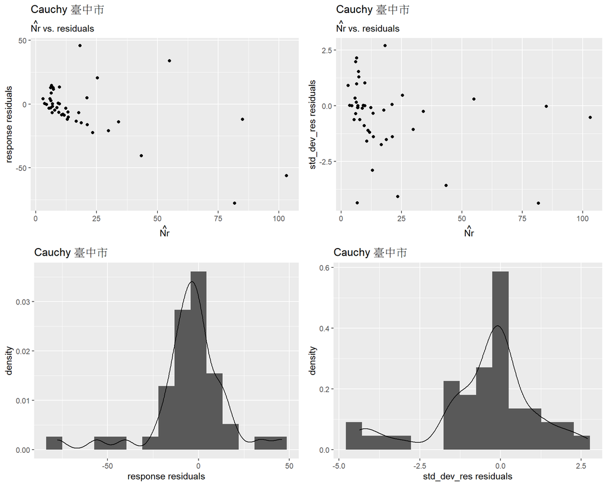

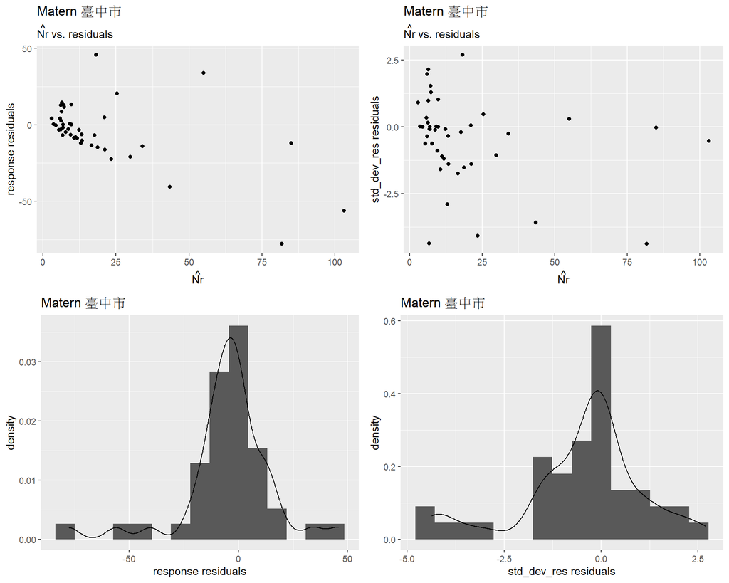

### Model 04

- package: spaMM
- family = negbin()
- 變數：層級(p.s. 台北市沒有)、戶量、里面積（平方公里）
- random slop
- 關聯矩陣：Cauchy、Matern (參數 `spaMM` 會給)

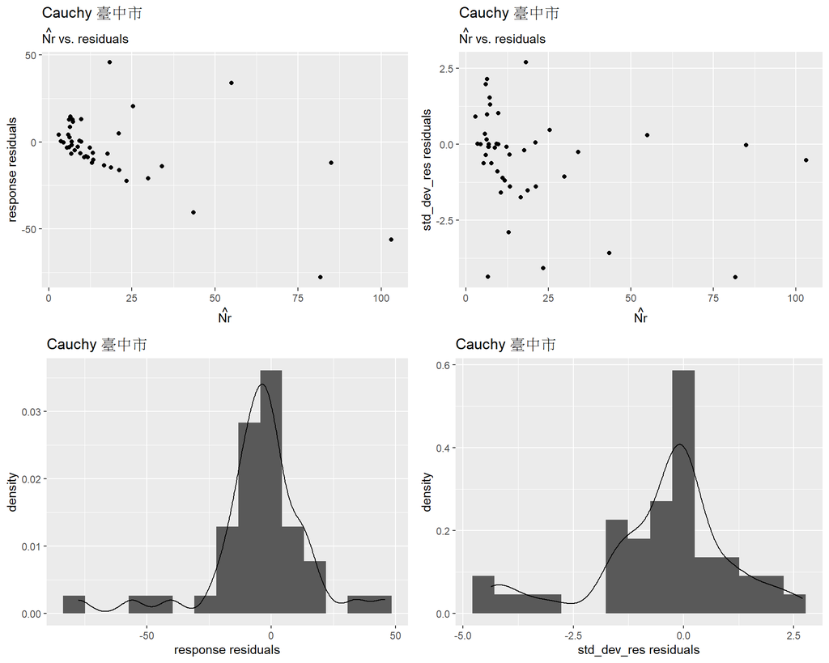

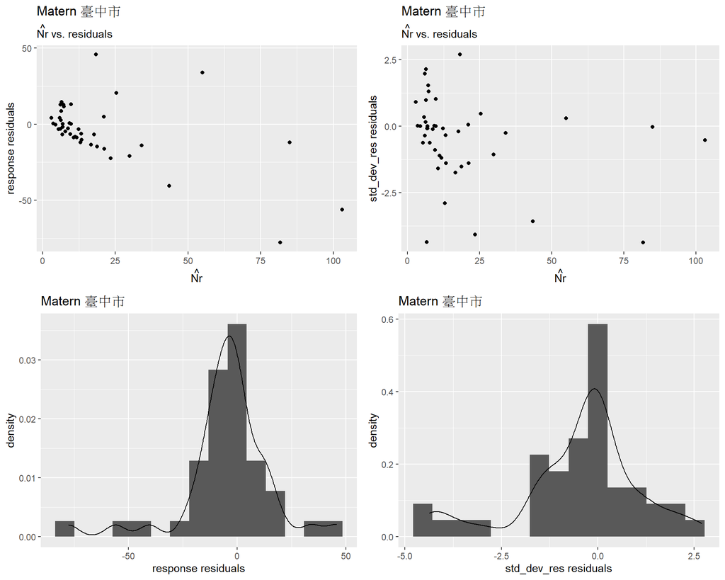

### Model 04

- package: spaMM
- family = COMPoisson()
- 變數：層級(p.s. 台北市沒有)、戶量、里面積（平方公里）
- random slop
- 關聯矩陣：Cauchy、Matern (參數 `spaMM` 會給)

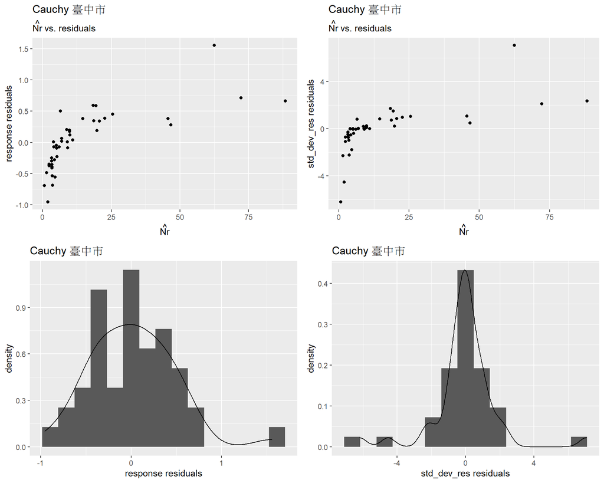

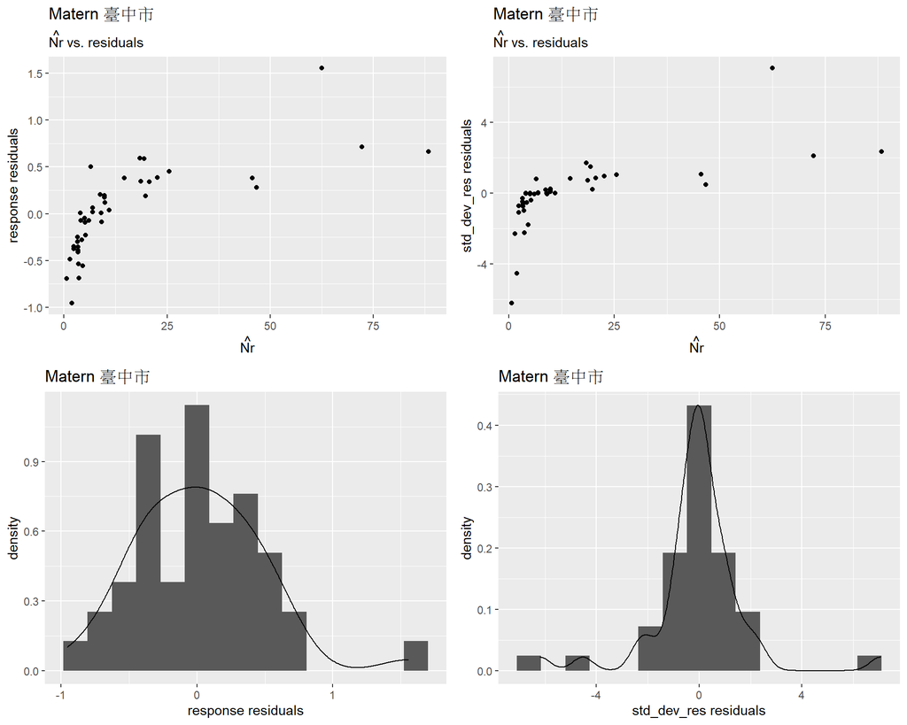